# Week 7: How much is a Fireplace Worth?

Shyni David

```r
library(tidyverse)
```

# Introduction

As the housing market continues to bounce around wildly, it is common to try to zero in on what qualities of a house add value and if so, how much. Another common task in the volatile house market is to predict the price of a house on the market based on its characteristics. A realtor may be more interested in simply learning which aspects of a home provide significant value and if so, how much?

For this project, we will examine a dataset of 1728 homes in Saratoga County, New York in 2006. 1228 will be available as the ‘training set’. With this set of data, you will perform analyses and build your model. The second set will be the test set. This includes 500 houses NOT used in the model building phase to test prediction in a set not included. The files are loaded below:

```r
train <- read_csv("https://raw.githubusercontent.com/jddbucknole/MAcc/master/HouseSaratogaTrain.csv")
test <- read_csv("https://raw.githubusercontent.com/jddbucknole/MAcc/master/HouseSaratogaTest.csv")
```

Included in the dataset are the following: A data frame with 1728 observations on the following 16 variables. * price - price (1000s of US dollars) * lotSize - size of lot (square feet) * age - age of house (years) * landValue - value of land (1000s of US dollars) * livingArea - living are (square feet) * pctCollege - percent of neighborhood that graduated college * bedrooms - number of bedrooms * fireplaces - number of fireplaces * bathrooms - number of bathrooms (half bathrooms have no shower or tub) * rooms - number of rooms * heating - type of heating system * fuel - fuel used for heating * sewer - type of sewer system * waterfront - whether property includes waterfront * newConstruction - whether the property is a new construction * centralAir - whether the house has central air * hasfireplace - whether the house has at least one fireplace

Your goal for this project contains 3 tasks (and a bonus). You may simply answer each question separately, but they will all necessitate a short paragraph (or more) of explanation and output. If you run computer analyses, provide relevant code and output.

# Part 1

Using the train data, discover if there is a significant difference in the average price of homes with a fireplace and homes without a fireplace (use the ‘hasfireplace’ variable). Make sure to report relevant statistics and potentially graphs to support your argument. Construct a 95% confidence interval for the difference in the average price of homes with and without fireplaces.

Houses with Fireplaces add high significance to home prices. The R2 is however very low 0.1051 which shows that the correlation is very insignificant. And the plot shows a pattern for the residuals.

```r
HomeMFP <- lm(price ~ factor(hasfireplace), data = train)
summary(HomeMFP)
```

```
##
## Call:
## lm(formula = price ~ factor(hasfireplace), data = train)
##
## Residuals:
##     Min      1Q  Median      3Q     Max
## -226458  -57810  -15813   42380  586133
##
## Coefficients:
##                       Estimate Std. Error t value Pr(>|t|)
## (Intercept)             173867       3979    43.7   <2e-16 ***
## factor(hasfireplace)1    62891       5240    12.0   <2e-16 ***
## ---
## Signif. codes:  0 '***' 0.001 '**' 0.01 '*' 0.05 '.' 0.1 ' ' 1
##
## Residual standard error: 90740 on 1226 degrees of freedom
## Multiple R-squared:  0.1051, Adjusted R-squared:  0.1044
## F-statistic:   144 on 1 and 1226 DF,  p-value: < 2.2e-16
```

```r
anova(HomeMFP)
```

```
## Analysis of Variance Table
##
## Response: price
##                        Df     Sum Sq    Mean Sq F value    Pr(>F)
## factor(hasfireplace)    1 1.1858e+12 1.1858e+12  144.03 < 2.2e-16 ***
## Residuals            1226 1.0094e+13 8.2333e+09
## ---
## Signif. codes:  0 '***' 0.001 '**' 0.01 '*' 0.05 '.' 0.1 ' ' 1
```

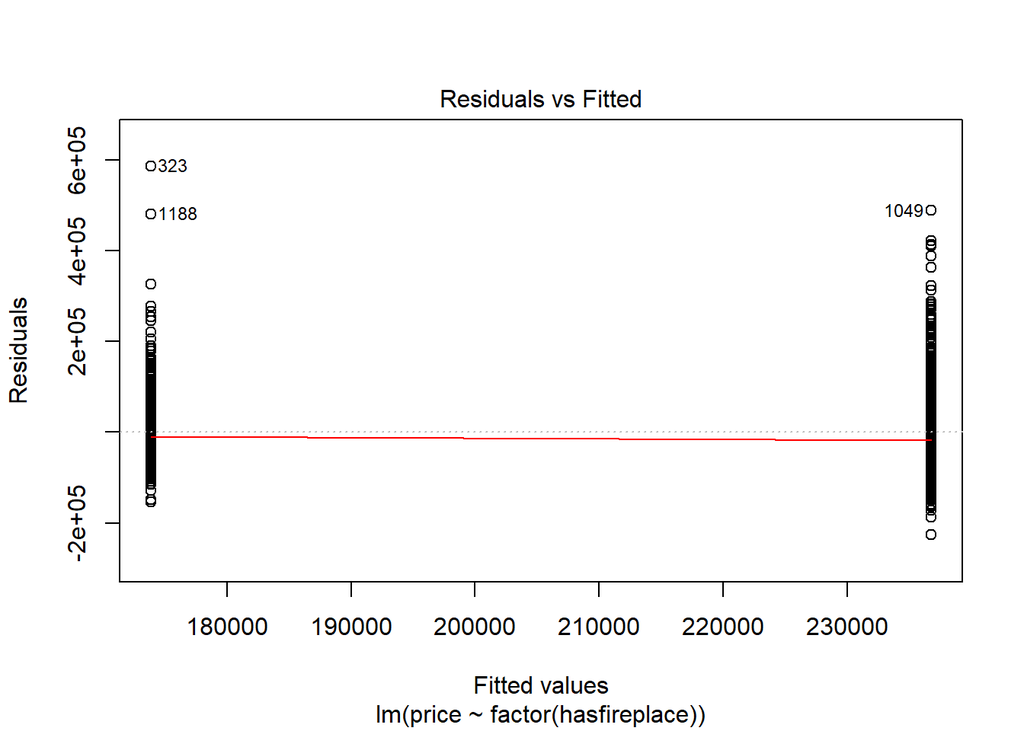

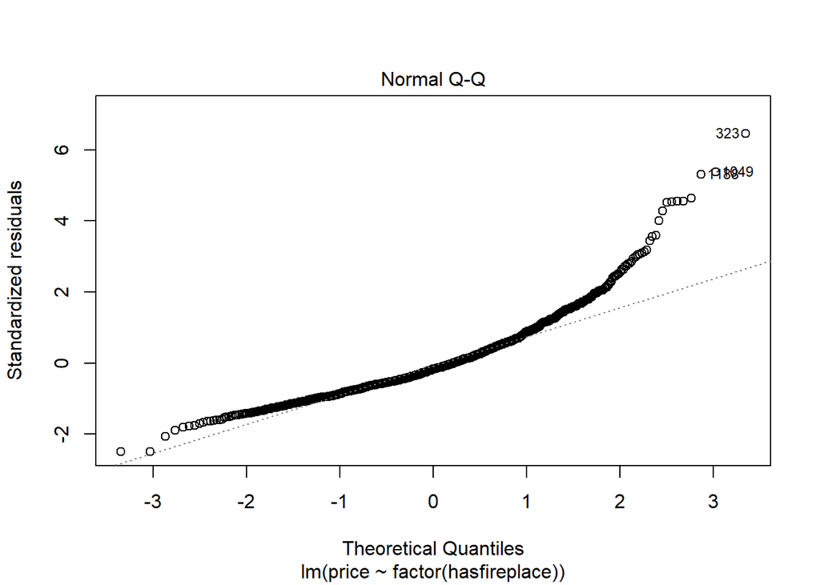

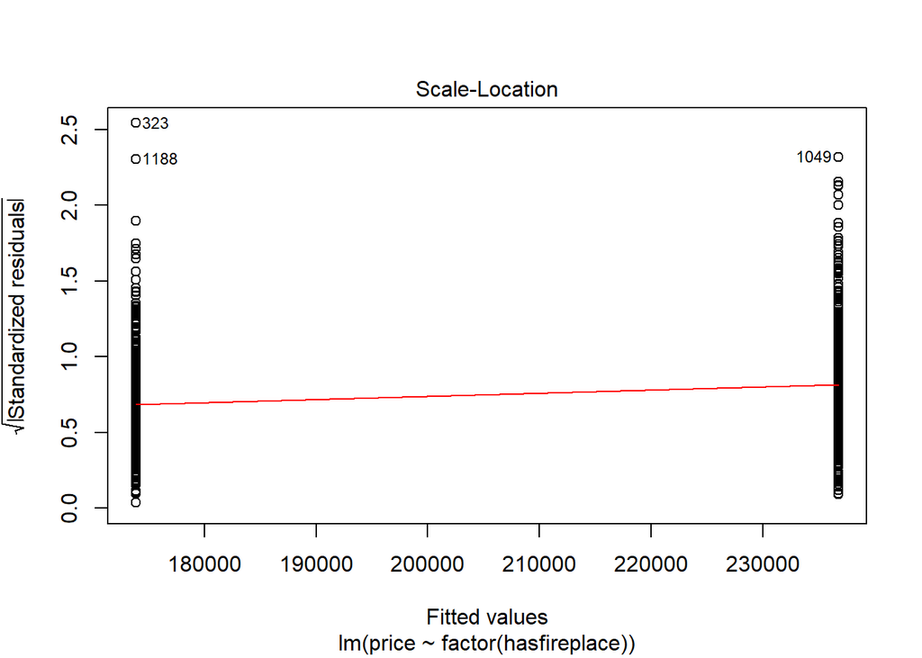

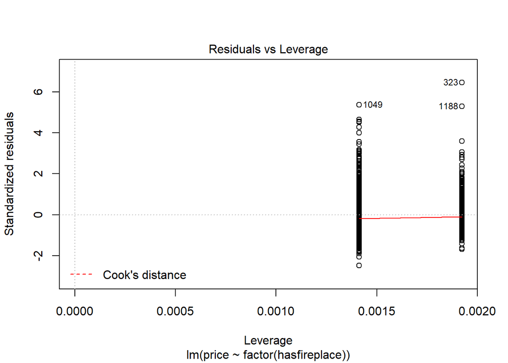

```r
plot(HomeMFP)
```

```r
t.test(price ~ factor(hasfireplace), data = train)
```

```
##
##  Welch Two Sample t-test
##
## data:  price by factor(hasfireplace)
## t = -12.479, df = 1223.2, p-value < 2.2e-16
## alternative hypothesis: true difference in means is not equal to 0
## 95 percent confidence interval:
##  -72778.38 -53003.16
## sample estimates:
## mean in group 0 mean in group 1
##        173867.2        236757.9
```

# Part 2

Fit a model to predict house price based on livingArea and hasfireplace. Explain what you find and how to interpret those coefficients. Your answer may be in conflict with question 1. Why? Is this a surprise? It is highly recommended to form a visualization to show these relationships.

The price increases by $111 for everey 1 sq ft of living area, but the living area is highly signicant in determining price as p value is very small. The price increases by $5107 if the house has fireplace but is also very insignificant due to high value of p.This is different from earlier observation.R2 is quite significant though with 50% correlation.

```r
HomeLF <- lm(price ~ livingArea+factor(hasfireplace), data = train)
summary(HomeLF)
```

```
##
## Call:
## lm(formula = price ~ livingArea + factor(hasfireplace), data = train)
##
## Residuals:
##     Min      1Q  Median      3Q     Max
## -171174  -40132   -6981   28046  555137
##
## Coefficients:
##                        Estimate Std. Error t value Pr(>|t|)
## (Intercept)           13159.262   5902.305   2.230    0.026 *
## livingArea              111.158      3.532  31.472   <2e-16 ***
## factor(hasfireplace)1  5107.073   4309.065   1.185    0.236
## ---
## Signif. codes:  0 '***' 0.001 '**' 0.01 '*' 0.05 '.' 0.1 ' ' 1
##
## Residual standard error: 67500 on 1225 degrees of freedom
## Multiple R-squared:  0.5052, Adjusted R-squared:  0.5044
## F-statistic: 625.4 on 2 and 1225 DF,  p-value: < 2.2e-16
```

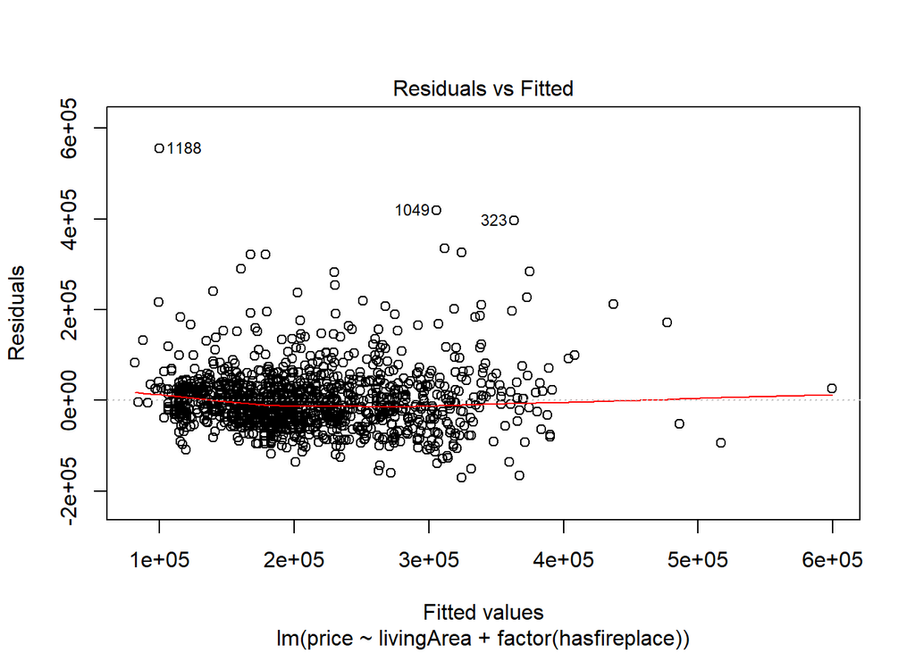

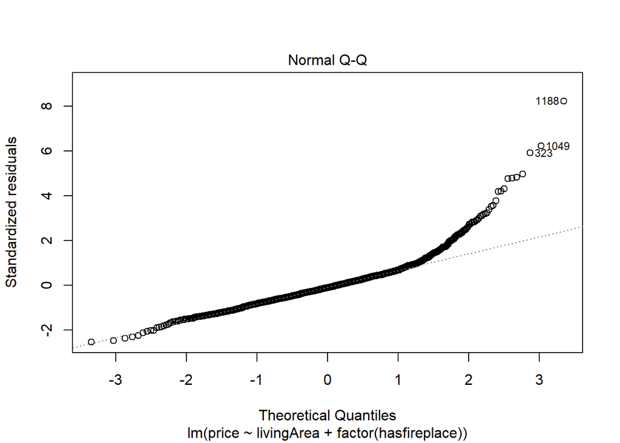

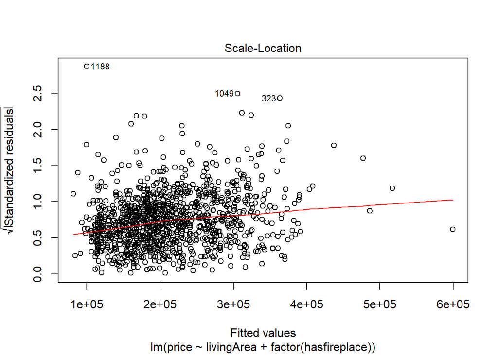

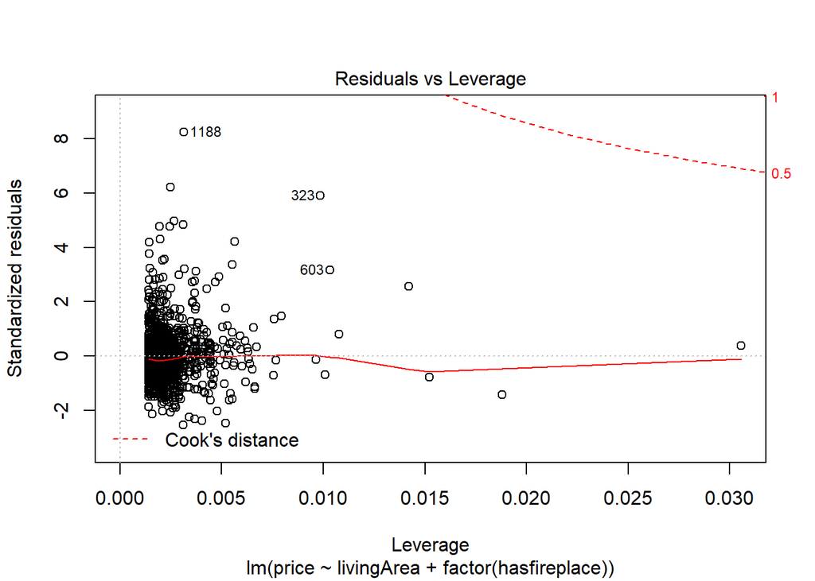

```r
plot(HomeLF)
```

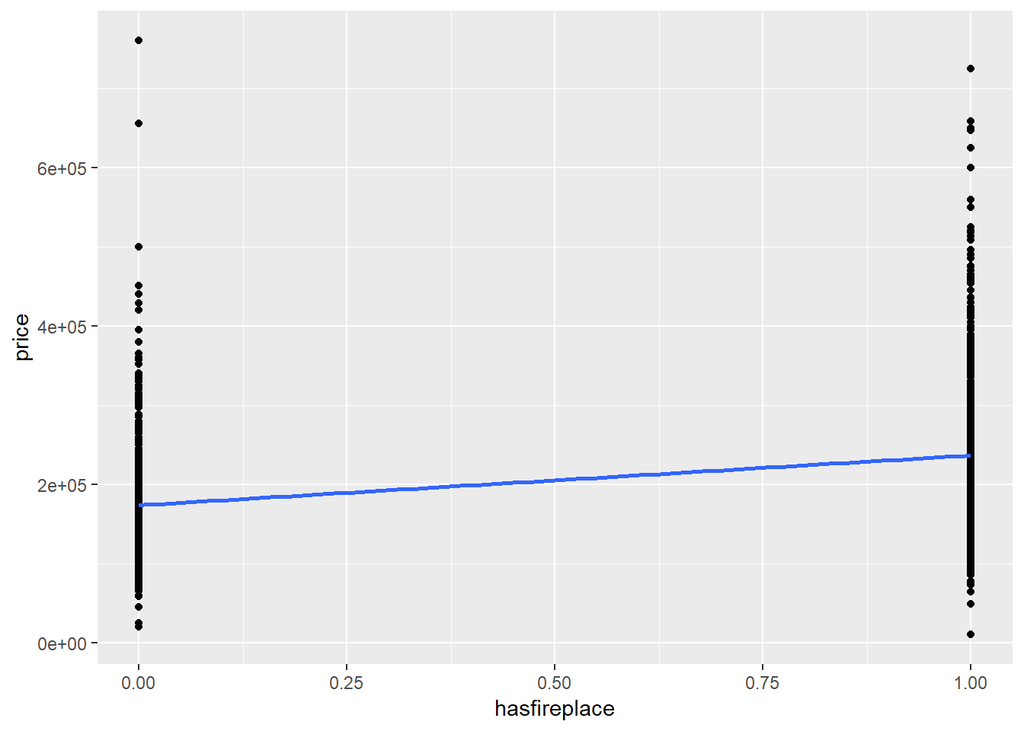

```r
ggplot(train ,aes(y= price, x= hasfireplace))+ geom_point()+geom_smooth(method="lm", se=F)
```

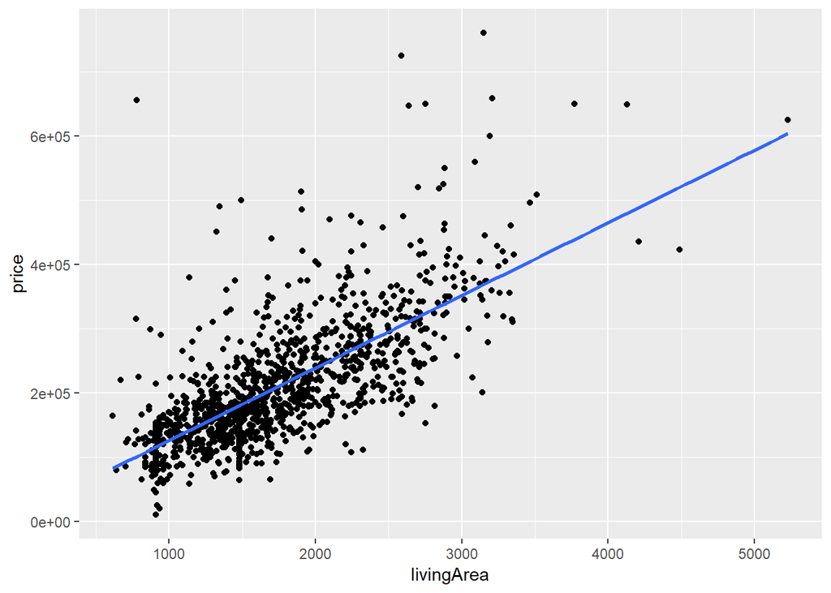

```r
ggplot(train ,aes(y= price, x= livingArea))+ geom_point()+geom_smooth(method="lm", se=F)
```

# Part 3

Fit the best model you can to predict price from the other factors. Use your own intuition, visualizations, and trial and error. What factors appear to be statistically and practically significant (and why)? Only report your final and supposed ‘best’ model. Do not look at the test set at all at this phase. Write a paragraph (or more) defending your model. Why were the predictors you included chosen? How do these different factors influence the price of the home? There is no single ‘correct’ answer here. I am more interested in your justification of the model you chose. Do NOT simply run a model that includes everything. That may be the best (or one of the best) according to some criteria, but it will likely not generalize to future predictions and have some severe collinearity concerns. Note: don’t include the hasfireplace and fireplaces variables together. I added the ‘hasfireplace’ variable so it wasn’t in the original dataset–severe collinearity warning!.

The model’s p value is significant with no collinearity between explanatory variables.The landvalue, livingArea and bathrooms are extremely significant. Electric heating is the baseline, hot air seems to be more signicant on pricing, hotwater and stream has negative slope indicating price decrease. Also as the age increases the negative slope indicates that the price decreases. R2 as 61% is fairly good. Fstat P value of the model is also significantly small, so the model is more fitting with the explanatory variables.

```r
bestmodel <- lm(price ~ lotSize+age+landValue+livingArea+fireplaces+bathrooms+rooms+heating, data = train)
summary(bestmodel)
```

```
##
## Call:
## lm(formula = price ~ lotSize + age + landValue + livingArea +
##     fireplaces + bathrooms + rooms + heating, data = train)
##
## Residuals:
##     Min      1Q  Median      3Q     Max
## -188929  -37119   -6089   26118  460498
##
## Coefficients:
##                          Estimate Std. Error t value Pr(>|t|)
## (Intercept)             2.722e+03  7.360e+03   0.370  0.71162
## lotSize                 6.751e+03  2.379e+03   2.838  0.00462 **
## age                    -1.546e+02  6.714e+01  -2.303  0.02142 *
## landValue               9.052e-01  5.637e-02  16.057  < 2e-16 ***
## livingArea              6.862e+01  5.449e+00  12.593  < 2e-16 ***
## fireplaces              1.196e+03  3.577e+03   0.334  0.73826
## bathrooms               2.112e+04  4.096e+03   5.157 2.93e-07 ***
## rooms                   1.337e+03  1.082e+03   1.235  0.21698
## heatinghot air          1.254e+04  4.909e+03   2.554  0.01076 *
## heatinghot water/steam -1.035e+03  6.231e+03  -0.166  0.86803
## ---
## Signif. codes:  0 '***' 0.001 '**' 0.01 '*' 0.05 '.' 0.1 ' ' 1
##
## Residual standard error: 59810 on 1218 degrees of freedom
## Multiple R-squared:  0.6137, Adjusted R-squared:  0.6109
## F-statistic:   215 on 9 and 1218 DF,  p-value: < 2.2e-16
```

```r
#install.packages("car")
library(car)
vif(bestmodel)
```

```
##                GVIF Df GVIF^(1/(2*Df))
## lotSize    1.026688  1        1.013256
## age        1.311568  1        1.145237
## landValue  1.215927  1        1.102691
## livingArea 3.704271  1        1.924648
## fireplaces 1.309668  1        1.144407
## bathrooms  2.401503  1        1.549678
## rooms      2.144443  1        1.464392
## heating    1.223298  2        1.051679
```

# For Fun

```r
#(RMSE <- sqrt(mean((predict(bestModel, test) - test$price)^2)))
```